# Project 3

Author

Hector Gavilanes

```r
library(tidyverse)
library(formattable)
library(lindia) # Influence & Leverage: gg_cooksd()
library(olsrr) #multicollinearity: ols_vif_tol()
library(car)
```

**Consider the insurance cost data availabile [here](https://github.com/stedy/Machine-Learning-with-R-datasets/blob/master/insurance.csv).**

**1. Import the data. Extra credit will be given to students that figure out how to directly import from GitHub.**

```r
# clear environment
rm(list = ls())
# extract data
data<-read.csv("https://raw.githubusercontent.com/stedy/Machine-Learning-with-R-datasets/master/insurance.csv")
```

**2. Fill in the following table:**

|  |  | Mean (Standard Deviation) or Number (Percent) |
| --- | --- | --- |
| Charges |  | SD = 12,110.01 Mean = 13,270.42 |
| Age |  | SD = 14.04996 Mean = 39.20703 |
| BMI |  | SD = 6.098 Mean = 30.663 |
| Sex | Male | Count = 676 Percent = 50.52% |
|  | Female | Count = 662 Percent = 49.48% |
| Smoking Status | Yes | Count = 274 Percent = 20.48% |
|  | No | Count = 1064 Percent = 79.52% |
| Number of Children | 0 | Count = 574 Percent = 42.9% |
|  | 1 | Count = 324 Percent = 24.22% |
|  | 2 | Count = 240 Percent = 17.94% |
|  | 3 | Count = 157 Percent = 11.73% |
|  | 4 | Count = 25 Percent = 1.87% |
|  | 5 | Count = 18 Percent = 1.35% |

```r
# get custom summary statistics
# !! sym() creates a symbol from a string
get_custom_summary <- function(data_table, numerical){
  data_table %>%
    # group_by(!! sym(category)) %>%
    summarise(SD = sd(!! sym(numerical)),
              Avg = mean(!! sym(numerical))
              )
}
get_custom_summary(data, "charges")
```

```
        SD      Avg
1 12110.01 13270.42
```

```r
get_custom_summary(data, "age")
```

```
        SD      Avg
1 14.04996 39.20703
```

```r
get_custom_summary(data, "bmi")
```

```
        SD     Avg
1 6.098187 30.6634
```

```r
get_count_percent <- function(categorical){
  total = length(categorical)
  c_count <- table(categorical)
  c_percent <- round(((c_count/total)*100), digits = 2)
  return(c(c_count, c_percent))
}
get_count_percent(data$sex)
```

```
female   male female   male
662.00 676.00  49.48  50.52
```

```r
get_count_percent(data$smoker)
```

```
     no     yes      no     yes
1064.00  274.00   79.52   20.48
```

```r
formattable(get_count_percent(data$children))
```

```
    0     1     2     3     4     5     0     1     2     3     4     5
  574   324   240   157    25    18  42.9 24.22 17.94 11.73  1.87  1.35
```

```r
# general summary
data %>%
  select(charges, age, bmi, children) %>%
  summary(data)
```

```
    charges           age             bmi           children
 Min.   : 1122   Min.   :18.00   Min.   :15.96   Min.   :0.000
 1st Qu.: 4740   1st Qu.:27.00   1st Qu.:26.30   1st Qu.:0.000
 Median : 9382   Median :39.00   Median :30.40   Median :1.000
 Mean   :13270   Mean   :39.21   Mean   :30.66   Mean   :1.095
 3rd Qu.:16640   3rd Qu.:51.00   3rd Qu.:34.69   3rd Qu.:2.000
 Max.   :63770   Max.   :64.00   Max.   :53.13   Max.   :5.000
```

```r
# Charges: Max vs 3rd-Quantile
(63770/16640-1)*100
```

```
[1] 283.2332
```

- There is a large difference between the Insurance Charges’ 75th percentile and the maximum value indicating the presence of potential outliers. Moreover, the difference represents 283.23% growth.
- Furthermore, there are high Standard Deviation for Insurance charges, Age, and BMI indicating the data points are more spread out above the mean.

**3. Model insurance charges as a function of age, BMI, and number of children. Remember to state the resulting model.**

```r
insurance_model <- lm(data$charges ~ data$age + data$bmi  + data$children)
summary(insurance_model)
```

```
Call:
lm(formula = data$charges ~ data$age + data$bmi + data$children)

Residuals:
   Min     1Q Median     3Q    Max
-13884  -6994  -5092   7125  48627

Coefficients:
              Estimate Std. Error t value Pr(>|t|)
(Intercept)   -6916.24    1757.48  -3.935 8.74e-05 ***
data$age        239.99      22.29  10.767  < 2e-16 ***
data$bmi        332.08      51.31   6.472 1.35e-10 ***
data$children   542.86     258.24   2.102   0.0357 *
---
Signif. codes:  0 '***' 0.001 '**' 0.01 '*' 0.05 '.' 0.1 ' ' 1

Residual standard error: 11370 on 1334 degrees of freedom
Multiple R-squared:  0.1201,    Adjusted R-squared:  0.1181
F-statistic: 60.69 on 3 and 1334 DF,  p-value: < 2.2e-16
```

## Model formula:

$$\hat{y} = -6916.24 + 240{\text{ age}} + 332.08{\text{ bmi}} + 542.9{\text{ children}}$$

**4. Provide brief and appropriate interpretations for all regression coefficients.**

- When Age, BMI, and Children are 0, we expect insurance charges to be at ($6,916.24).
- As Age increase by 1 year, the insurance charges increases by $240, after controlling for BMI, and Children.
- As BMI increase by 1 point, the insurance charges increases by $332.08, after controlling for Age, and Children.
- As Children increase by 1 kid, the insurance charges increases by $542.9, after controlling for BMI, and Age.
- $R^2_{adj}$ is 0.1181 - 11.81% of the variability in insurance charges are explained by the model with age, bmi, and number of children.

**5. Fill in the following table:**

| Predictor | $\hat{\beta}_i$ (95% CI) | *p*-Value |
| --- | --- | --- |
| Age | 240 (196.27, 283.72) | < 0.001 |
| BMI | 332.08 (231.43, 432.74) | < 0.001 |
| Number of Children | 542.9 (36.26, 1,049.47) | 0.0357 |

```r
confint(insurance_model)
```

```
                     2.5 %     97.5 %
(Intercept)   -10363.96835 -3468.5183
data$age         196.26940   283.7195
data$bmi         231.42538   432.7414
data$children     36.26142  1049.4679
```

**(yes, I am asking you to place both the estimated $\beta$ as well as the corresponding 95% CI in the cell.)**

**6. Which, if any, are significant predictors of insurance charges? Test at the $\alpha=0.05$ level. You do not need to state all hypothesis test pieces, but you must provide appropriate justification for your conclusions.**

- Age, BMI, and Children variables are significant predictors.

##### Determine if Age is a significant predictor of insurance charges

- Reject $H_0$ at the $\alpha=0.05$ level. After adjusting for insurance charges, there is sufficient evidence to suggest that *Age* is a significant predictor with a $p < 0.001$.

##### Determine if BMI is a significant predictor of insurance charges

- Reject $H_0$ at the $\alpha=0.05$ level. After adjusting for insurance charges, there is sufficient evidence to suggest that *BMI* is a significant predictor with a $p < 0.001$.

##### Determine if Children is a significant predictor of insurance charges

- Reject $H_0$ at the $\alpha=0.05$ level. After adjusting for insurance charges, there is sufficient evidence to suggest that *Children* is a significant predictor with a $p = 0.0357$.

**7. Use the appropriate hypothesis test to determine if this is a significant regression line. Test at the $\alpha=0.05$ level.**

**Hypotheses**

- $H_0: \beta_{charges} = \beta_{age} = \beta_{bmi} = \beta_{children} = 0$
- $H_1:$ at least one $\beta_i$ is different.

**Test Statistic and *p*-value**

- $F_0 = 60.69$
- $p < 0.001$

**Conclusion/Interpretation**

- Reject $H_0$ at the $\alpha=0.05$ level. There is sufficient evidence to suggest that at least one variable is a significant predictor of insurance charges.

**8. Construct the correlation matrix for the variables in the regression model. Are any suspiciously high?**

```r
# calculate Pearson's correlation matrix
insurance_matrix <- data %>%
  select(charges, age, bmi, children)
cor(insurance_matrix,
    method = "pearson",
    use = "complete.obs")
```

```
            charges       age       bmi   children
charges  1.00000000 0.2990082 0.1983410 0.06799823
age      0.29900819 1.0000000 0.1092719 0.04246900
bmi      0.19834097 0.1092719 1.0000000 0.01275890
children 0.06799823 0.0424690 0.0127589 1.00000000
```

```r
# calculate Spearman's correlation matrix
cor(insurance_matrix,
    method = "spearman",
    use = "complete.obs")
```

```
           charges        age        bmi   children
charges  1.0000000 0.53439213 0.11939590 0.13333894
age      0.5343921 1.00000000 0.10773604 0.05699222
bmi      0.1193959 0.10773604 1.00000000 0.01560674
children 0.1333389 0.05699222 0.01560674 1.00000000
```

- We have tested for parametric, and non-parametric correlations.
- Overall, the correlations have very low scores. No suspicious high values.
- The non-parametric test shows a medium correlation between Insurance Charges, and Age.

**9. Check for outliers. How many are there?**

```r
# count outliers in the model
n = 2.5
outlier_data <- data %>%
  mutate(Outlier = abs(rstandard(insurance_model)) > n)
formattable(outlier_data) %>% count(Outlier)
```

| Outlier | n |
| --- | --- |
| FALSE | 1327 |
| TRUE | 11 |

```r
# get outliers
positive_outlier <- outlier_data %>%
  select(age, bmi, children, charges, Outlier) %>%
  drop_na() %>%
  mutate(obs = row_number())
formattable(positive_outlier) %>%
  filter(Outlier == TRUE)
```

| age | bmi | children | charges | Outlier | obs |
| --- | --- | --- | --- | --- | --- |
| 28 | 36.400 | 1 | 51194.56 | TRUE | 35 |
| 44 | 38.060 | 0 | 48885.14 | TRUE | 489 |
| 54 | 47.410 | 0 | 63770.43 | TRUE | 544 |
| 31 | 38.095 | 1 | 58571.07 | TRUE | 578 |
| 34 | 30.210 | 1 | 43943.88 | TRUE | 588 |
| 29 | 35.500 | 2 | 44585.46 | TRUE | 740 |
| 33 | 35.530 | 0 | 55135.40 | TRUE | 820 |
| 19 | 32.490 | 0 | 36898.73 | TRUE | 1140 |
| 60 | 32.800 | 0 | 52590.83 | TRUE | 1147 |
| 52 | 34.485 | 3 | 60021.40 | TRUE | 1231 |
| 45 | 30.360 | 0 | 62592.87 | TRUE | 1301 |

**10. Check for influential/leverage points. How many are there?**

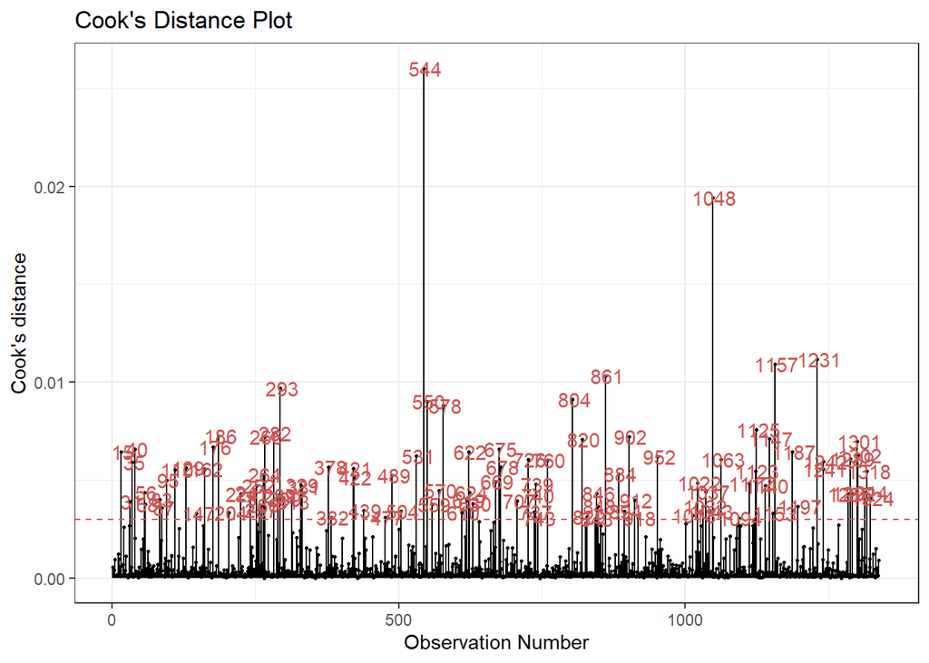

```r
gg_cooksd(insurance_model) + theme_bw()
```

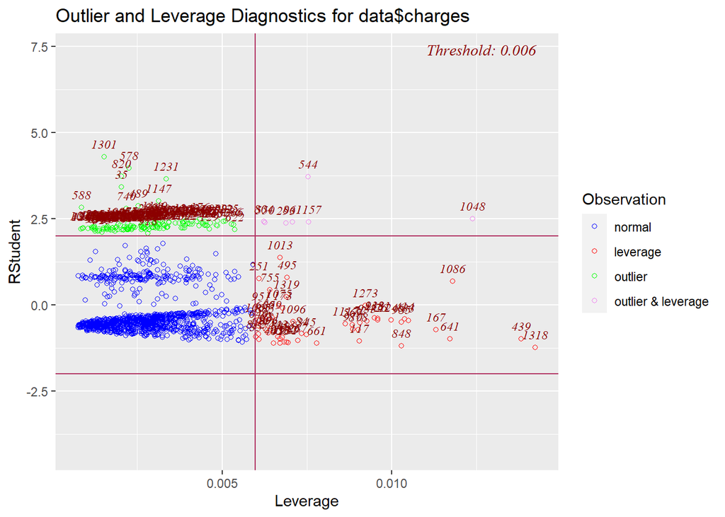

```r
ols_plot_resid_lev(insurance_model)
```

- Points 544, 1048 need further investigation.
- However, there are more outliers that could represent potential issues for the model.

**11. Check for multicollinearity. Do the results surprise you?**

```r
ols_vif_tol(insurance_model)
```

```
      Variables Tolerance      VIF
1      data$age 0.9863722 1.013816
2      data$bmi 0.9879936 1.012152
3 data$children 0.9981297 1.001874
```

-No multicollinearity is present.

**12. Construct a graph to aid with explanation of the regression model. Create lines for 0, 2, and 4 children. You pick what goes on the *x*-axis and what is plugged in for the remaining variable. Extra credit if you make the outlier dots a different color than the non-outlier dots.**

#### Added-Variable Plots

The Added-Variable plots allow us to observe the relationship between each individual predictor variable and the response variable while holding other predictor variables constant.

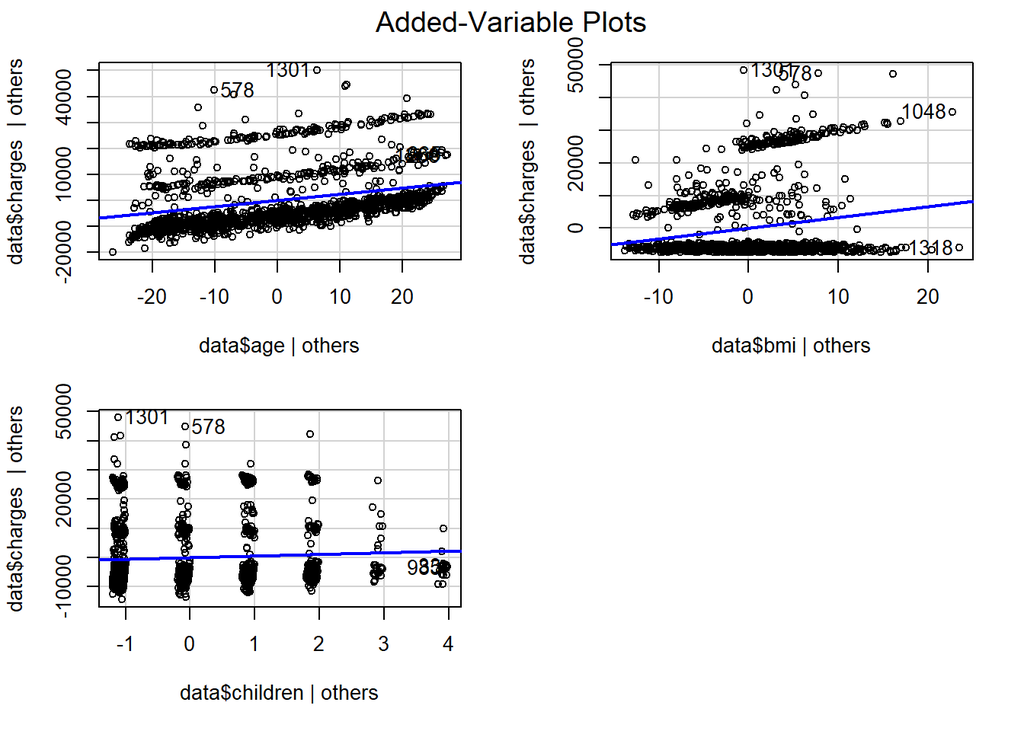

```r
avPlots(insurance_model)
```

- The points that are labeled in each plot represent the observations with the largest residuals and the observations with the largest partial leverage.

#### Visualization with GGPlot

```r
# insurance_model <- lm(charges ~ age + bmi  + children)

# check for specific outliers observations
outlier_color <- positive_outlier %>%
  filter(obs == 544 | obs == 1048)
outlier_color
```

```
  age   bmi children  charges Outlier  obs
1  54 47.41        0 63770.43    TRUE  544
2  22 52.58        1 44501.40   FALSE 1048
```

```r
# get coefficients
c1 <- coefficients(insurance_model)
c1
```

```
  (Intercept)      data$age      data$bmi data$children
   -6916.2433      239.9945      332.0834      542.8647
```

```r
# Plug in for Children
quantile(data$children, na.rm = TRUE)
```

```
  0%  25%  50%  75% 100%
   0    0    1    2    5
```

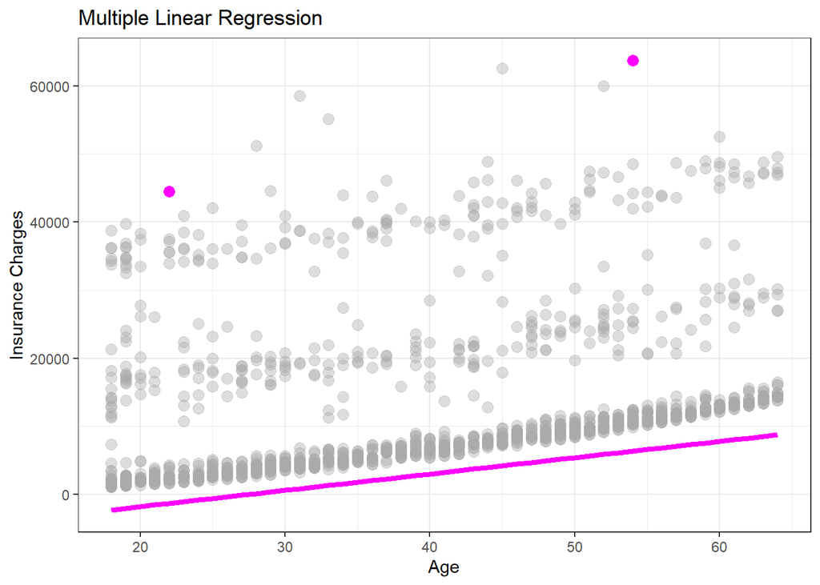

```r
# create lines graph for Children of 0, 2, 4
# Age on the X-axis
gg_data <- data %>%
  mutate(c0 = c1[1] + c1[2]*data$age + c1[3], + c1[4]*0,
         c2 = c1[1] + c1[2]*data$age + c1[3], + c1[4]*2,
         c4 = c1[1] + c1[2]*data$age + c1[3], + c1[4]*4)

# ggplot graph
age_plot <- gg_data %>% ggplot(aes(x = age, y = charges)) +
  geom_point(color = "darkgray", size=3, alpha = 0.4) +
  geom_point(data = outlier_color, color = "magenta", size = 3) +
  geom_line(aes(y = c0), color = "orange") +
  geom_line(aes(y = c2), color = "cyan") +
  geom_line(aes(y = c4), color = "magenta", size = 1.5) +
  labs(title = "Multiple Linear Regression",
       x = "Age",
       y = "Insurance Charges") +
  theme_bw()

age_plot
```

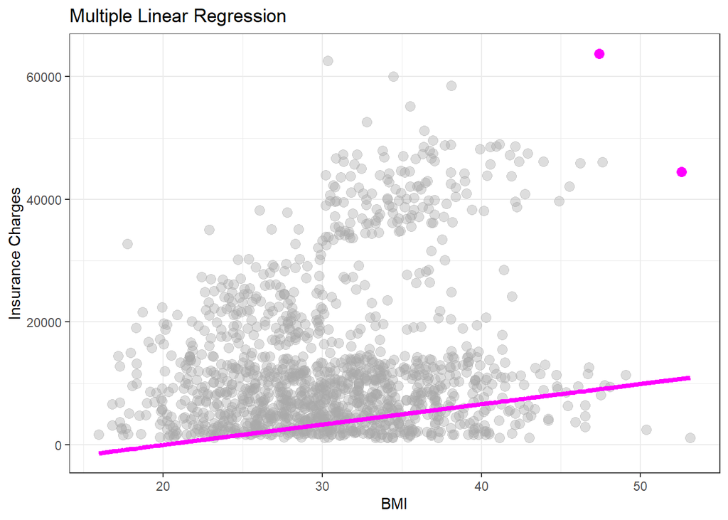

```r
# create lines graph for Children of 0, 2, 4
# bmi on the x-axis
gg_data <- data %>%
  mutate(c0 = c1[1] + c1[2] + c1[3]*data$bmi, + c1[4]*0,
         c2 = c1[1] + c1[2] + c1[3]*data$bmi, + c1[4]*2,
         c4 = c1[1] + c1[2] + c1[3]*data$bmi, + c1[4]*4)

# ggplot graph
bmi_plot <- gg_data %>% ggplot(aes(x = bmi, y = charges)) +
  geom_point(color = "darkgray", size=3, alpha = 0.4) +
  geom_point(data = outlier_color, color = "magenta", size = 3) +
  geom_line(aes(y = c0), color = "orange") +
  geom_line(aes(y = c2), color = "cyan") +
  geom_line(aes(y = c4), color = "magenta", size = 1.5) +
  labs(title = "Multiple Linear Regression",
       x = "BMI",
       y = "Insurance Charges") +
  theme_bw()

bmi_plot
```

**13. Write a short paragraph to accompany your results, appropriate for your supervisor who is not a statistician or data scientist. Outline your modeling technique as well as the summary of the data (i.e., the first table) and results.**

## Conclusion

The model did not fit well. We have detected and investigated points: 544 and 1048. However, there are more outliers that caused issues for the model. Therefore, we suggest to explore the other categorical predictors such as sex, region, or smoking status to find relevant data that can help to create a more robust model.

#### Summary Statistics

|  |  | Mean (Standard Deviation) or Number (Percent) |
| --- | --- | --- |
| Charges |  | SD = 12,110.01 Mean = 13,270.42 |
| Age |  | SD = 14.04996 Mean = 39.20703 |
| BMI |  | SD = 6.098 Mean = 30.663 |
| Sex | Male | Count = 676 Percent = 50.52% |
|  | Female | Count = 662 Percent = 49.48% |
| Smoking Status | Yes | Count = 274 Percent = 20.48% |
|  | No | Count = 1064 Percent = 79.52% |
| Number of Children | 0 | Count = 574 Percent = 42.9% |
|  | 1 | Count = 324 Percent = 24.22% |
|  | 2 | Count = 240 Percent = 17.94% |
|  | 3 | Count = 157 Percent = 11.73% |
|  | 4 | Count = 25 Percent = 1.87% |
|  | 5 | Count = 18 Percent = 1.35% |

- A significant difference between the insurance charges’ 75th percentile and the maximum value indicated the presence of potential outliers. Moreover, the difference represented 283.23% growth.
- Furthermore, a high Standard Deviation for Insurance charges, Age, and BMI indicated the data points were more spread out above the mean.

#### Regression Model

```
Call:
lm(formula = data$charges ~ data$age + data$bmi + data$children)

Residuals:
   Min     1Q Median     3Q    Max
-13884  -6994  -5092   7125  48627

Coefficients:
              Estimate Std. Error t value Pr(>|t|)
(Intercept)   -6916.24    1757.48  -3.935 8.74e-05 ***
data$age        239.99      22.29  10.767  < 2e-16 ***
data$bmi        332.08      51.31   6.472 1.35e-10 ***
data$children   542.86     258.24   2.102   0.0357 *
---
Signif. codes:  0 '***' 0.001 '**' 0.01 '*' 0.05 '.' 0.1 ' ' 1

Residual standard error: 11370 on 1334 degrees of freedom
Multiple R-squared:  0.1201,    Adjusted R-squared:  0.1181
F-statistic: 60.69 on 3 and 1334 DF,  p-value: < 2.2e-16
```

#### Model formula:

$$\hat{y} = -6916.24 + 240{\text{ age}} + 332.08{\text{ bmi}} + 542.9{\text{ children}}$$

#### Model Interpretation

- When Age, BMI, and Children are 0, we expect insurance charges to be at ($6,916.24).
- As Age increase by 1 year, the insurance charges increases by $240, after controlling for BMI, and Children.
- As BMI increase by 1 point, the insurance charges increases by $332.08, after controlling for Age, and Children.
- As Children increase by 1 kid, the insurance charges increases by $542.9, after controlling for BMI, and Age.
- $R^2_{adj}$ is 0.1181 - 11.81% of the variability in insurance charges are explained by the model with age, bmi, and number of children.

#### Confidence Intervals

A table was generated to compare the confidence intervals with coefficients, and p-Values.

| Predictor | $\hat{\beta}_i$ (95% CI) | *p*-Value |
| --- | --- | --- |
| Age | 240 (196.269, 283.719) | < 0.001 |
| BMI | 332.08 (231.425, 432.741) | < 0.001 |
| Number of Children | 542.9 (36.261, 1,049.468) | 0.0357 |

```
                     2.5 %     97.5 %
(Intercept)   -10363.96835 -3468.5183
data$age         196.26940   283.7195
data$bmi         231.42538   432.7414
data$children     36.26142  1049.4679
```

#### Significant Predictors

- Age, BMI, and Children variables were significant predictors.

##### Determine if Age is a significant predictor of insurance charges

- Reject $H_0$ at the $\alpha=0.05$ level. After adjusting for insurance charges, there is sufficient evidence to suggest that *Age* is a significant predictor with a $p < 0.001$.

##### Determine if BMI is a significant predictor of insurance charges

- Reject $H_0$ at the $\alpha=0.05$ level. After adjusting for insurance charges, there is sufficient evidence to suggest that *BMI* is a significant predictor with a $p < 0.001$.

##### Determine if Children is a significant predictor of insurance charges

- Reject $H_0$ at the $\alpha=0.05$ level. After adjusting for insurance charges, there is sufficient evidence to suggest that *Children* is a significant predictor with a $p = 0.0357$.

#### Significant Regression Line

**Hypotheses**

- $H_0: \beta_{charges} = \beta_{age} = \beta_{bmi} = \beta_{children} = 0$
- $H_1:$ at least one $\beta_i$ is different.

**Test Statistic and *p*-value**

- $F_0 = 60.69$
- $p < 0.001$

**Conclusion/Interpretation**

- Reject $H_0$ at the $\alpha=0.05$ level. There was sufficient evidence to suggest that at least one variable was a significant predictor of insurance charges.

#### Correlations

```
            charges       age       bmi   children
charges  1.00000000 0.2990082 0.1983410 0.06799823
age      0.29900819 1.0000000 0.1092719 0.04246900
bmi      0.19834097 0.1092719 1.0000000 0.01275890
children 0.06799823 0.0424690 0.0127589 1.00000000
```

```
           charges        age        bmi   children
charges  1.0000000 0.53439213 0.11939590 0.13333894
age      0.5343921 1.00000000 0.10773604 0.05699222
bmi      0.1193959 0.10773604 1.00000000 0.01560674
children 0.1333389 0.05699222 0.01560674 1.00000000
```

- We have tested for parametric, and non-parametric correlations.
- Overall, the correlations had very low scores. No suspicious high values.
- The non-parametric test showed a medium correlation of 0.534 between Insurance Charges, and Age.

#### Outliers

The following test reported 11 outliers.

| Outlier | n |
| --- | --- |
| FALSE | 1327 |
| TRUE | 11 |

| age | bmi | children | charges | Outlier | obs |
| --- | --- | --- | --- | --- | --- |
| 28 | 36.400 | 1 | 51194.56 | TRUE | 35 |
| 44 | 38.060 | 0 | 48885.14 | TRUE | 489 |
| 54 | 47.410 | 0 | 63770.43 | TRUE | 544 |
| 31 | 38.095 | 1 | 58571.07 | TRUE | 578 |
| 34 | 30.210 | 1 | 43943.88 | TRUE | 588 |
| 29 | 35.500 | 2 | 44585.46 | TRUE | 740 |
| 33 | 35.530 | 0 | 55135.40 | TRUE | 820 |
| 19 | 32.490 | 0 | 36898.73 | TRUE | 1140 |
| 60 | 32.800 | 0 | 52590.83 | TRUE | 1147 |
| 52 | 34.485 | 3 | 60021.40 | TRUE | 1231 |
| 45 | 30.360 | 0 | 62592.87 | TRUE | 1301 |

#### Influential and Leverage Points

The following graphs displayed that a lot of points had high leverage, and high influence.

- Points 544, 1048 needed further investigation.
- However, there are more outliers that could represent potential issues for the model.

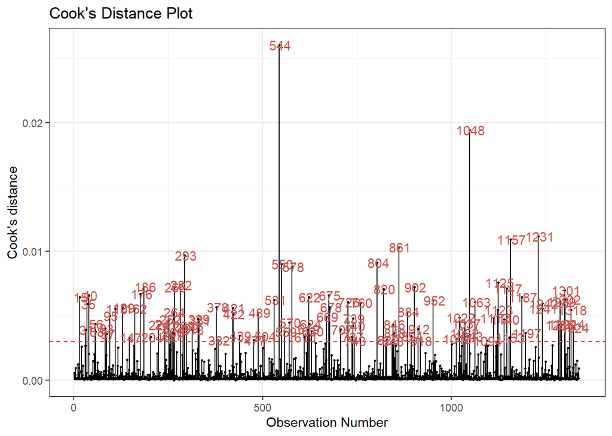

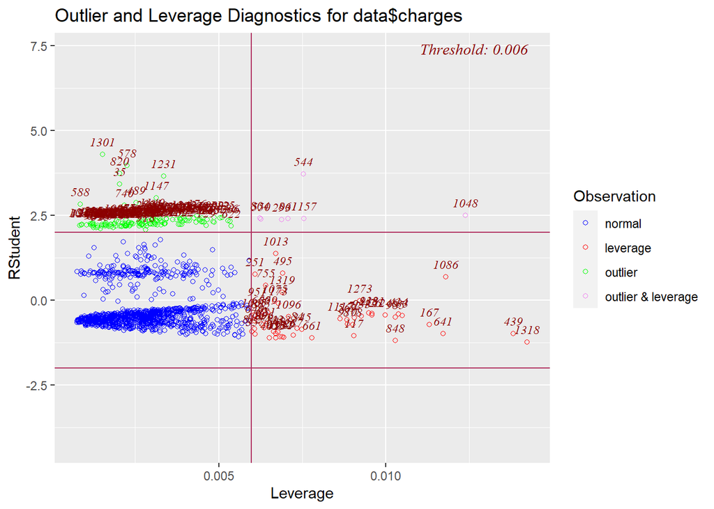

#### Multicollinearity

-No multicollinearity was present.

```
      Variables Tolerance      VIF
1      data$age 0.9863722 1.013816
2      data$bmi 0.9879936 1.012152
3 data$children 0.9981297 1.001874
```

### Visualization of the Model

#### Added-Variable Plots

The Added-Variable plots allowed us to observe the relationship between each individual predictor variable and the response variable while holding other predictor variables constant.

- The labeled points in each plot represented the observations with the largest residuals and the observations with the largest partial leverage.

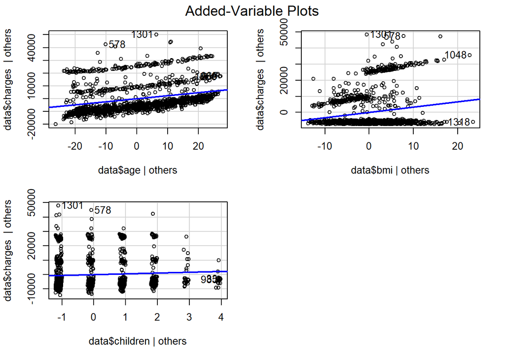

#### Visualization for Age on the X-axis

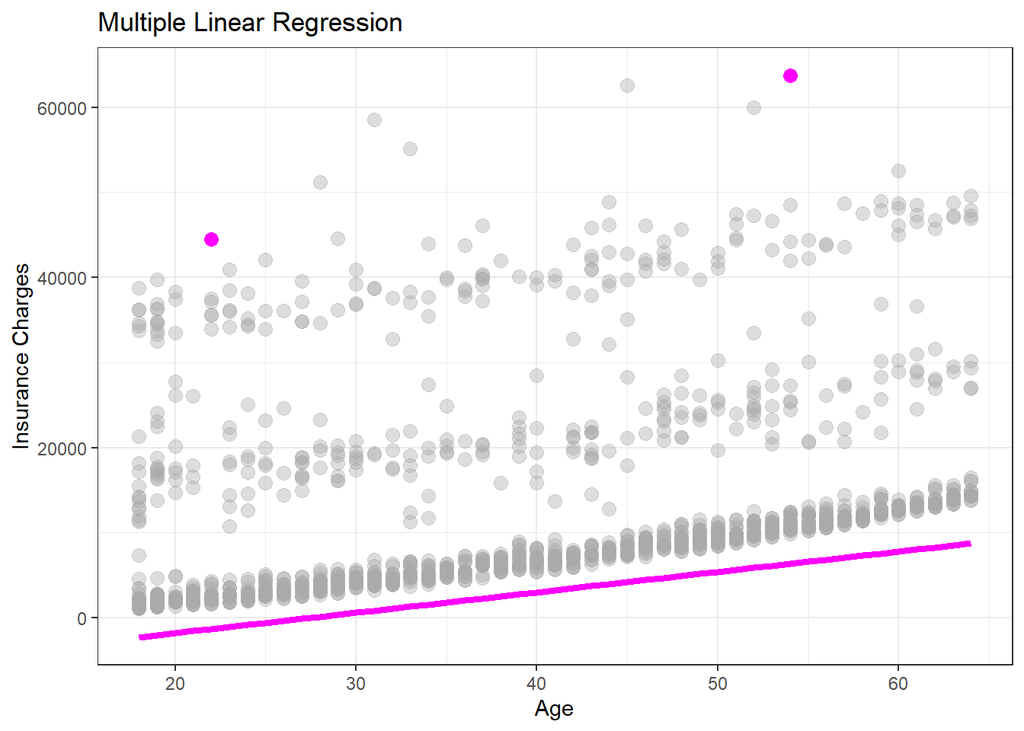

#### Visualization for BMI on the X-axis

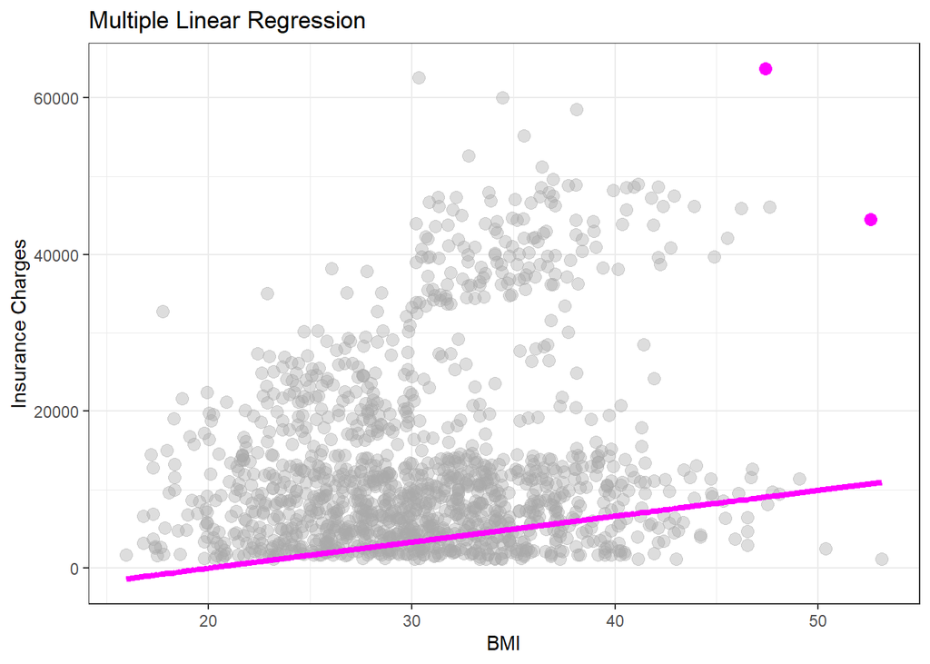